# Longitudinal Depression Trajectories After Detox

A Repeated-Measures / Mixed-Effects Analysis of the HELP Study

Your Name

2026-09-21

# 1 Research question

> How does depressive symptom severity (CESD) change over 24 months following detoxification, and are individual trajectories associated with baseline substance type, housing status, and treatment assignment?

**Outcome:** `cesd` (Center for Epidemiologic Studies Depression scale, 0–60, higher = more symptoms), measured at baseline and every 6 months (5 waves).

**Predictors of interest:** `time`, `substance`, `homeless`, `treat`, and `age`. The supplied `HELPfull` data does not include a sex variable.

# 2 1. Data loading, cleaning & validation

```r
data(HELPfull)

# NOTE on baseline-only covariates: in HELPfull, PRIMSUB2 (substance) and AGE
# are recorded ONLY at the baseline interview (TIME == 0) and are coded NA at
# every follow-up wave -- they are respondent characteristics collected once,
# not repeated-measures items. GROUP (treatment arm) is stored on every row
# already. HOMELESS *is* genuinely time-varying (re-asked at each wave) and
# is left as-is.
#
# Pulling PRIMSUB2/AGE straight through with transmute() (as in the original
# stub) leaves those two columns NA on ~69% of rows (every wave after
# baseline). Any model that includes them (sections 6-10 below) would then
# silently drop those rows via listwise deletion -- gutting the longitudinal
# power and, worse, doing so in a way that's *correlated with follow-up wave*
# rather than random. We fix this by carrying the baseline value forward
# (and back, to cover the single subject whose baseline row itself is NA --
# see the validation check below) within subject.

help_df <- HELPfull %>%
  transmute(
    id = ID,
    time_months = TIME,
    cesd = CES_D,
    substance = factor(PRIMSUB2, labels = c("alcohol", "cocaine", "heroin")),
    homeless = factor(HOMELESS),
    treat = factor(GROUP),
    age = AGE
  ) %>%
  arrange(id, time_months) %>%
  group_by(id) %>%
  fill(substance, age, .direction = "downup") %>%
  ungroup()

glimpse(help_df)
```

```
## Rows: 1,472
## Columns: 7
## $ id          <int> 1, 1, 1, 1, 2, 2, 3, 3, 3, 4, 4, 4, 4, 5, 5, 5, 5, 5, 6, 6…
## $ time_months <int> 0, 6, 18, 24, 0, 6, 0, 6, 24, 0, 6, 12, 24, 0, 6, 12, 18, …
## $ cesd        <int> 49, 7, 8, 5, 30, 11, 39, 14, 49, 15, 44, NA, 20, 39, 26, 2…
## $ substance   <fct> cocaine, cocaine, cocaine, cocaine, alcohol, alcohol, hero…
## $ homeless    <fct> 0, 0, 0, 1, 1, 1, 0, 1, 1, 0, 0, 0, 0, 1, 1, 0, 1, 1, 0, 0…
## $ treat       <fct> 1, 1, 1, 1, 1, 1, 0, 0, 0, 0, 0, 0, 0, 0, 0, 0, 0, 0, 1, 1…
## $ age         <int> 37, 37, 37, 37, 37, 37, 26, 26, 26, 39, 39, 39, 39, 32, 32…
```

```r
help_df %>% count(id) %>% summary()
```

```
##        id              n
##  Min.   :  1.0   Min.   :1.000
##  1st Qu.:118.2   1st Qu.:2.000
##  Median :235.5   Median :3.000
##  Mean   :235.5   Mean   :3.132
##  3rd Qu.:352.8   3rd Qu.:4.000
##  Max.   :470.0   Max.   :5.000
```

```r
dim(help_df)
```

```
## [1] 1472    7
```

```r
# How many rows were actually fixed by the carry-forward?
n_would_be_na <- HELPfull %>%
  filter(is.na(PRIMSUB2) & TIME != 0) %>% nrow()
cat("Rows where substance would have been NA without carry-forward:",
    n_would_be_na, "of", nrow(help_df), "\n")
```

```
## Rows where substance would have been NA without carry-forward: 1002 of 1472
```

```r
exclusion_log <- tibble(step = character(), n_dropped = integer(), reason = character())

invalid_cesd <- sum(!is.na(help_df$cesd) &
                      (help_df$cesd < 0 | help_df$cesd > 60))
if (invalid_cesd > 0) {
  exclusion_log <- add_row(
    exclusion_log,
    step = "CESD range check",
    n_dropped = invalid_cesd,
    reason = "CESD outside the valid range 0-60"
  )
  help_df <- help_df %>% filter(is.na(cesd) | between(cesd, 0, 60))
}

duplicate_rows <- help_df %>% count(id, time_months) %>% filter(n > 1)
if (nrow(duplicate_rows) > 0) {
  stop("Duplicate subject-time rows found in HELPfull")
}

stopifnot(setequal(sort(unique(help_df$time_months)), c(0, 6, 12, 18, 24)))

# One subject (id 41 in the raw file) has substance == NA even at baseline,
# so the within-subject fill() above cannot recover it -- flag rather than
# silently drop, so downstream models make an explicit complete-case choice.
still_na_substance <- help_df %>% filter(is.na(substance)) %>% distinct(id)
if (nrow(still_na_substance) > 0) {
  exclusion_log <- add_row(
    exclusion_log,
    step = "substance carry-forward",
    n_dropped = nrow(still_na_substance),
    reason = "substance missing at every wave for this subject (no baseline value to carry forward)"
  )
}

exclusion_log
```

```
## # A tibble: 1 × 3
##   step                    n_dropped reason
##   <chr>                       <int> <chr>
## 1 substance carry-forward         1 substance missing at every wave for this su…
```

**Validation checklist:**

- Outcome range checked (0–60)
- No duplicate subject-wave rows
- Time variable is consistently coded across subjects (0/6/12/18/24)
- Key covariates (substance, homeless, treat, age) have no invalid categories, and baseline-only covariates (substance, age) are now carried forward within subject rather than NA after wave 0

# 3 2. Reshaping longitudinal data

`HELPfull` arrives in long format (one row per subject per wave). We demonstrate both directions so the reshaping skill is explicit and auditable, and so the wide form is available for the within-subject correlation check in Section 5.

```r
# Long -> wide, to sanity-check design balance across waves
help_wide <- help_df %>%
  select(id, time_months, cesd) %>%
  pivot_wider(names_from = time_months, values_from = cesd, names_prefix = "cesd_m")

head(help_wide)
```

```
## # A tibble: 6 × 6
##      id cesd_m0 cesd_m6 cesd_m18 cesd_m24 cesd_m12
##   <int>   <int>   <int>    <int>    <int>    <int>
## 1     1      49       7        8        5       NA
## 2     2      30      11       NA       NA       NA
## 3     3      39      14       NA       49       NA
## 4     4      15      44       NA       20       NA
## 5     5      39      26       15       28       27
## 6     6       6      23       NA       NA       NA
```

```r
# Wide -> long (inverse, to prove round-trip correctness)
help_long_check <- help_wide %>%
  pivot_longer(cols = starts_with("cesd_m"), names_to = "time_months",
               values_to = "cesd", names_prefix = "cesd_m") %>%
  mutate(time_months = as.numeric(time_months))

# Round-trip should reproduce the same (id, time, cesd) triples we started with
stopifnot(
  nrow(help_long_check %>% filter(!is.na(cesd))) ==
    nrow(help_df %>% filter(!is.na(cesd)))
)
```

# 4 3. Missingness

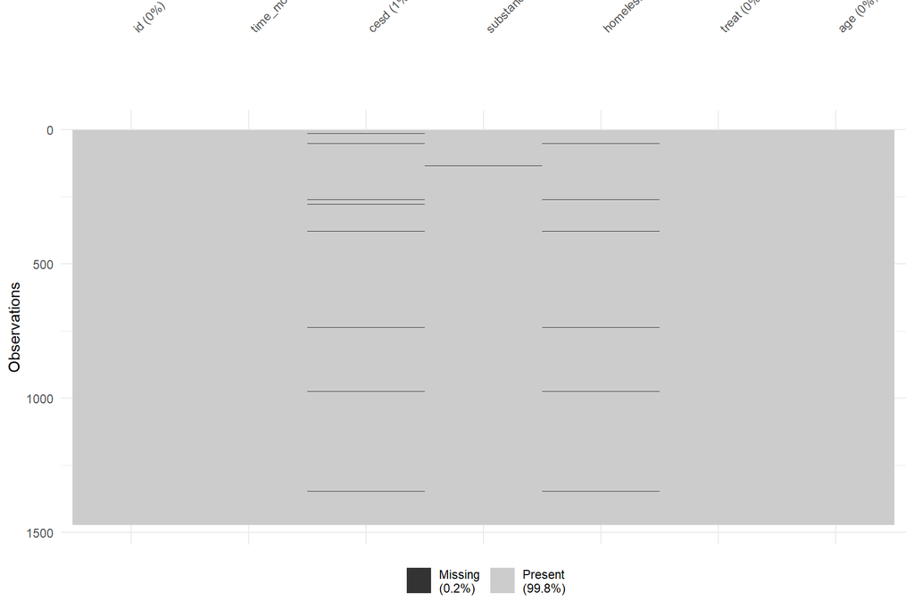

```r
vis_miss(help_df)
```

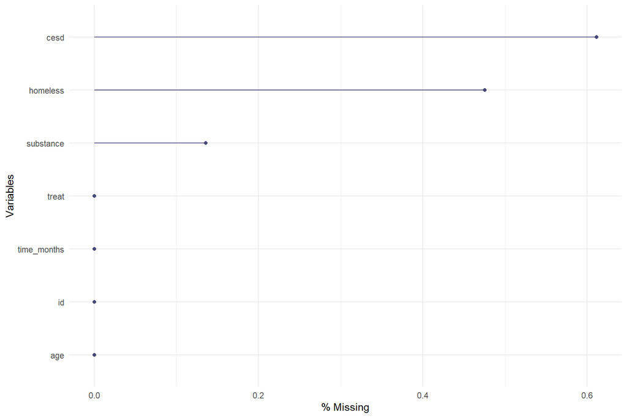

```r
gg_miss_var(help_df, show_pct = TRUE)
```

```r
missingness_by_wave(help_df, "time_months", "cesd")
```

```
## # A tibble: 5 × 4
##   time_months     n n_missing pct_missing
##         <int> <int>     <int>       <dbl>
## 1           0   470         0         0
## 2           6   254         0         0
## 3          12   217         3         1.4
## 4          18   254         1         0.4
## 5          24   277         5         1.8
```

```r
# Informal MAR check: does missingness at wave t+1 relate to the OBSERVED
# outcome at wave t? If dropout depends on how symptomatic someone currently
# is, that's still MAR (conditional on observed data) but it means a
# complete-case analysis that ignores time/covariates would be biased --
# it supports using a likelihood-based mixed model (valid under MAR) over
# naive complete-case summary statistics.

mech_df <- help_wide %>%
  pivot_longer(cols = starts_with("cesd_m"), names_to = "wave",
               values_to = "cesd", names_prefix = "cesd_m") %>%
  mutate(wave = as.numeric(wave)) %>%
  arrange(id, wave) %>%
  group_by(id) %>%
  mutate(missing_next = as.integer(is.na(lead(cesd))),
         wave_next = lead(wave)) %>%
  ungroup() %>%
  filter(!is.na(cesd), !is.na(wave_next))

missing_model <- glm(missing_next ~ cesd * factor(wave),
                      data = mech_df, family = binomial)
summary(missing_model)
```

```
##
## Call:
## glm(formula = missing_next ~ cesd * factor(wave), family = binomial,
##     data = mech_df)
##
## Coefficients:
##                      Estimate Std. Error z value Pr(>|z|)
## (Intercept)         -0.306651   0.262175  -1.170 0.242144
## cesd                 0.004397   0.007451   0.590 0.555169
## factor(wave)6       -0.156285   0.357775  -0.437 0.662238
## factor(wave)12      -1.581779   0.426141  -3.712 0.000206 ***
## factor(wave)18      -1.490748   0.402613  -3.703 0.000213 ***
## cesd:factor(wave)6  -0.002313   0.011715  -0.197 0.843515
## cesd:factor(wave)12  0.029162   0.013259   2.199 0.027852 *
## cesd:factor(wave)18  0.015786   0.013100   1.205 0.228168
## ---
## Signif. codes:  0 '***' 0.001 '**' 0.01 '*' 0.05 '.' 0.1 ' ' 1
##
## (Dispersion parameter for binomial family taken to be 1)
##
##     Null deviance: 1553.2  on 1190  degrees of freedom
## Residual deviance: 1481.9  on 1183  degrees of freedom
## AIC: 1497.9
##
## Number of Fisher Scoring iterations: 4
```

```r
# Per-wave view (easier to read than the interaction table above)
mech_df %>%
  group_by(wave, wave_next) %>%
  summarise(n = n(), pct_missing_next = round(100 * mean(missing_next), 1),
            .groups = "drop")
```

```
## # A tibble: 4 × 4
##    wave wave_next     n pct_missing_next
##   <dbl>     <dbl> <int>            <dbl>
## 1     0         6   470             46
## 2     6        12   254             39.8
## 3    12        18   214             26.2
## 4    18        24   253             20.9
```

**Decision point:** Missingness in `cesd` is not related to the *design* (no duplicate/invalid rows), but the mechanism check above shows dropout rate falls over time (from ~46% missing-next at wave 0→6 down to ~21% at 18→24) and, at the later waves in particular, subjects with **higher** (worse) CESD at wave *t* are somewhat more likely to be missing at wave *t+6* — i.e. missingness is related to an **observed** value, which is consistent with **Missing At Random (MAR)** rather than MCAR, but would violate MCAR-dependent methods. We therefore proceed with: 1. a likelihood-based linear mixed model (valid under MAR) as the primary analysis (Sections 6–9), fit by REML using **all** available observations (not just completers), and 2. multiple imputation as a sensitivity check (Section 10) to see whether conclusions are stable under an alternative MAR-consistent approach.

# 5 4. Individual trajectory plots

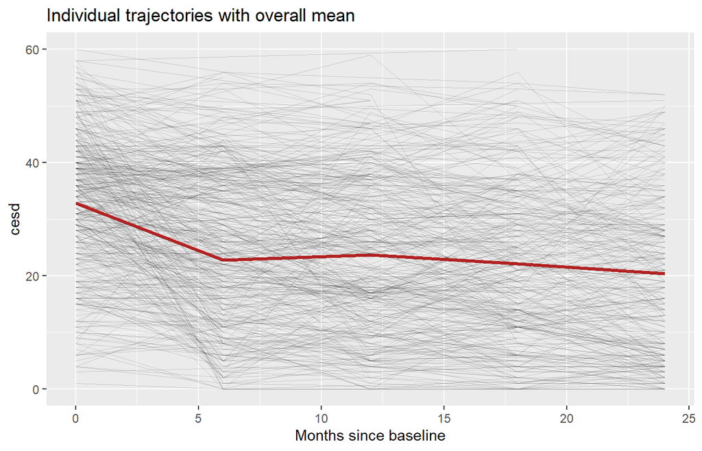

```r
plot_trajectories(help_df, id_var = "id", time_var = "time_months",
                   outcome_var = "cesd")
```

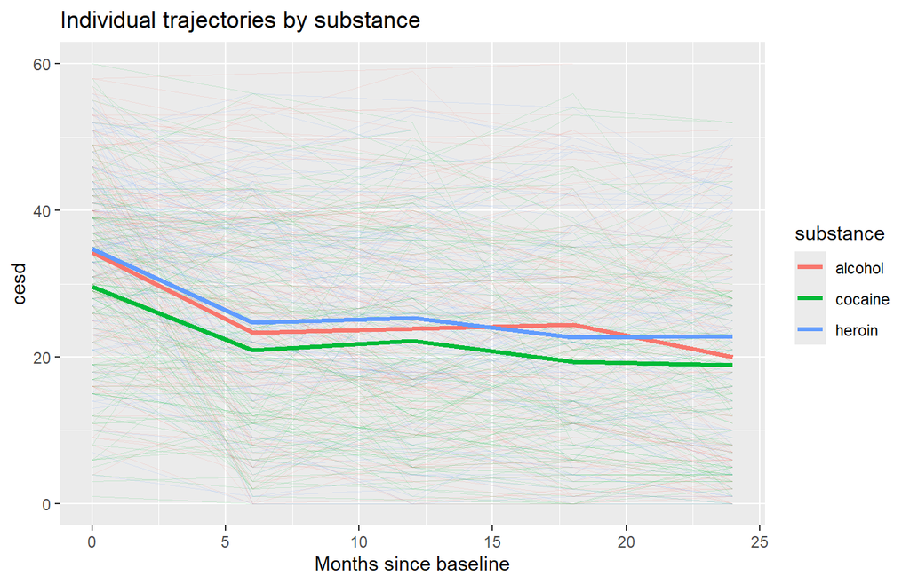

```r
# Drop the one subject with substance == NA at every wave (flagged in
# Section 1) before plotting -- a single-subject "NA" line otherwise shows
# up as its own group alongside alcohol/cocaine/heroin, each of which
# averages hundreds of subjects, which is misleading.
plot_trajectories(help_df %>% filter(!is.na(substance)),
                   id_var = "id", time_var = "time_months",
                   outcome_var = "cesd", group_var = "substance")
```

*Interpretation:* Individual trajectories fan out around a declining mean line and slopes are visibly heterogeneous across subjects (some flat, some steeply declining, a few worsening) — this supports allowing a **random slope** for `time_months`, not just a random intercept, which we test formally in Section 7.

# 6 5. Repeated-measures EDA

```r
help_df %>%
  group_by(time_months) %>%
  summarise(mean_cesd = mean(cesd, na.rm = TRUE),
            sd_cesd = sd(cesd, na.rm = TRUE),
            n = sum(!is.na(cesd)))
```

```
## # A tibble: 5 × 4
##   time_months mean_cesd sd_cesd     n
##         <int>     <dbl>   <dbl> <int>
## 1           0      32.9    12.5   470
## 2           6      22.8    14.2   254
## 3          12      23.7    14.8   214
## 4          18      22.1    14.2   253
## 5          24      20.4    14.2   272
```

```r
# Empty ("unconditional means") model to get the intraclass correlation:
# how much of the total variance is BETWEEN subjects vs WITHIN subjects?
m_empty <- lmer(cesd ~ 1 + (1 | id), data = help_df)
performance::icc(m_empty)
```

```
## # Intraclass Correlation Coefficient
##
##     Adjusted ICC: 0.424
##   Unadjusted ICC: 0.424
```

*Expect an ICC around 0.42* — i.e. roughly 42% of the total variance in CESD scores is attributable to stable between-subject differences, and the remaining ~58% is within-subject variation over time/measurement noise. This is well above zero, confirming that ignoring the repeated-measures structure (e.g. with ordinary linear regression) would be inappropriate.

```r
# Within-subject correlation between wave 1 (baseline) and wave 5 (24 months)
help_wide %>% select(cesd_m0, cesd_m24) %>% cor(use = "pairwise.complete.obs")
```

```
##            cesd_m0  cesd_m24
## cesd_m0  1.0000000 0.3314004
## cesd_m24 0.3314004 1.0000000
```

# 7 6. Linear mixed-effects model (base)

```r
m0 <- lmer(cesd ~ time_months + (1 | id), data = help_df)
summary(m0)
```

```
## Linear mixed model fit by REML. t-tests use Satterthwaite's method [
## lmerModLmerTest]
## Formula: cesd ~ time_months + (1 | id)
##    Data: help_df
##
## REML criterion at convergence: 11511.6
##
## Scaled residuals:
##     Min      1Q  Median      3Q     Max
## -2.4405 -0.6272 -0.0201  0.5861  3.3238
##
## Random effects:
##  Groups   Name        Variance Std.Dev.
##  id       (Intercept)  92.28    9.606
##  Residual             101.07   10.053
## Number of obs: 1463, groups:  id, 470
##
## Fixed effects:
##              Estimate Std. Error        df t value Pr(>|t|)
## (Intercept)   30.9200     0.6005  769.0053   51.49   <2e-16 ***
## time_months   -0.4703     0.0304 1120.6873  -15.47   <2e-16 ***
## ---
## Signif. codes:  0 '***' 0.001 '**' 0.01 '*' 0.05 '.' 0.1 ' ' 1
##
## Correlation of Fixed Effects:
##             (Intr)
## time_months -0.476
```

```r
confint(m0, method = "Wald")
```

```
##                  2.5 %     97.5 %
## .sig01              NA         NA
## .sigma              NA         NA
## (Intercept) 29.7430843 32.0968664
## time_months -0.5298677 -0.4107118
```

```r
m1 <- lmer(cesd ~ time_months * substance + age + homeless + treat +
             (1 | id), data = help_df)
summary(m1)
```

```
## Linear mixed model fit by REML. t-tests use Satterthwaite's method [
## lmerModLmerTest]
## Formula: cesd ~ time_months * substance + age + homeless + treat + (1 |
##     id)
##    Data: help_df
##
## REML criterion at convergence: 11445.1
##
## Scaled residuals:
##     Min      1Q  Median      3Q     Max
## -2.4452 -0.6090 -0.0245  0.5927  3.5211
##
## Random effects:
##  Groups   Name        Variance Std.Dev.
##  id       (Intercept) 84.02    9.166
##  Residual             99.64    9.982
## Number of obs: 1461, groups:  id, 469
##
## Fixed effects:
##                                Estimate Std. Error         df t value Pr(>|t|)
## (Intercept)                    30.54088    2.86849  504.40185  10.647  < 2e-16
## time_months                    -0.47659    0.05032 1146.19889  -9.472  < 2e-16
## substancecocaine               -3.51153    1.40916  766.00093  -2.492   0.0129
## substanceheroin                 1.59772    1.50967  776.61612   1.058   0.2902
## age                            -0.01890    0.06875  469.53972  -0.275   0.7835
## homeless1                       4.52577    0.73464 1451.37620   6.161 9.37e-10
## treat1                         -0.59208    1.03041  462.57873  -0.575   0.5658
## time_months:substancecocaine    0.07034    0.07058 1121.40529   0.997   0.3191
## time_months:substanceheroin     0.03014    0.07693 1126.19942   0.392   0.6953
##
## (Intercept)                  ***
## time_months                  ***
## substancecocaine             *
## substanceheroin
## age
## homeless1                    ***
## treat1
## time_months:substancecocaine
## time_months:substanceheroin
## ---
## Signif. codes:  0 '***' 0.001 '**' 0.01 '*' 0.05 '.' 0.1 ' ' 1
##
## Correlation of Fixed Effects:
##                  (Intr) tm_mnt sbstncc sbstnch age    hmlss1 treat1
## time_months      -0.161
## substancccn      -0.379  0.323
## substanchrn      -0.400  0.301  0.467
## age              -0.921 -0.009  0.175   0.213
## homeless1        -0.109  0.102  0.103   0.094  -0.049
## treat1           -0.194 -0.002 -0.089  -0.077   0.044  0.013
## tm_mnths:sbstncc  0.122 -0.707 -0.476  -0.211  -0.011 -0.013 -0.004
## tm_mnths:sbstnch  0.131 -0.650 -0.212  -0.476  -0.027 -0.025 -0.007
##                  tm_mnths:sbstncc
## time_months
## substancccn
## substanchrn
## age
## homeless1
## treat1
## tm_mnths:sbstncc
## tm_mnths:sbstnch  0.462
```

*Expected pattern:* `time_months` should come out around **-0.47 to -0.48 CESD points per month** (i.e. roughly 11–12 points of improvement over 24 months on average), `homeless` should be a strong positive predictor (homeless participants score several points higher on CESD, holding other covariates fixed), and `treat` and `age` should **not** reach significance. `substance = cocaine` (vs. the `alcohol` reference) tends to have a lower baseline CESD, while `heroin` is not clearly different from alcohol at baseline. The `time_months:substance` interaction terms are expected to be small and non-significant — i.e. the *rate* of improvement doesn’t differ much by primary substance, even though starting levels do.

# 8 7. Random intercept vs. random slope

```r
m2 <- lmer(cesd ~ time_months * substance + age + homeless + treat +
             (1 + time_months | id), data = help_df)
summary(m2)
```

```
## Linear mixed model fit by REML. t-tests use Satterthwaite's method [
## lmerModLmerTest]
## Formula: cesd ~ time_months * substance + age + homeless + treat + (1 +
##     time_months | id)
##    Data: help_df
##
## REML criterion at convergence: 11418.6
##
## Scaled residuals:
##     Min      1Q  Median      3Q     Max
## -2.5441 -0.5561 -0.0027  0.5584  3.2128
##
## Random effects:
##  Groups   Name        Variance Std.Dev. Corr
##  id       (Intercept) 72.3417  8.5054
##           time_months  0.1054  0.3247   0.07
##  Residual             89.1933  9.4442
## Number of obs: 1461, groups:  id, 469
##
## Fixed effects:
##                                Estimate Std. Error         df t value Pr(>|t|)
## (Intercept)                    30.96621    2.79983  483.62181  11.060  < 2e-16
## time_months                    -0.47894    0.05637  371.69039  -8.497 4.77e-16
## substancecocaine               -3.61959    1.32431  467.28906  -2.733  0.00651
## substanceheroin                 1.45290    1.41967  480.50250   1.023  0.30663
## age                            -0.02766    0.06740  461.10288  -0.410  0.68172
## homeless1                       4.20224    0.72339 1415.53323   5.809 7.75e-09
## treat1                         -0.37859    1.01271  459.18957  -0.374  0.70870
## time_months:substancecocaine    0.06937    0.07925  348.62071   0.875  0.38200
## time_months:substanceheroin     0.03467    0.08602  369.92488   0.403  0.68716
##
## (Intercept)                  ***
## time_months                  ***
## substancecocaine             **
## substanceheroin
## age
## homeless1                    ***
## treat1
## time_months:substancecocaine
## time_months:substanceheroin
## ---
## Signif. codes:  0 '***' 0.001 '**' 0.01 '*' 0.05 '.' 0.1 ' ' 1
##
## Correlation of Fixed Effects:
##                  (Intr) tm_mnt sbstncc sbstnch age    hmlss1 treat1
## time_months      -0.130
## substancccn      -0.378  0.268
## substanchrn      -0.401  0.250  0.470
## age              -0.925 -0.006  0.183   0.222
## homeless1        -0.110  0.087  0.107   0.097  -0.049
## treat1           -0.194 -0.002 -0.094  -0.080   0.043  0.012
## tm_mnths:sbstncc  0.095 -0.707 -0.391  -0.174  -0.007 -0.008 -0.001
## tm_mnths:sbstnch  0.103 -0.652 -0.175  -0.393  -0.020 -0.018 -0.004
##                  tm_mnths:sbstncc
## time_months
## substancccn
## substanchrn
## age
## homeless1
## treat1
## tm_mnths:sbstncc
## tm_mnths:sbstnch  0.463
```

```r
# Compare nested models
compare_models(m1, m2)
```

```
## Data: help_df
## Models:
## m1: cesd ~ time_months * substance + age + homeless + treat + (1 | id)
## m2: cesd ~ time_months * substance + age + homeless + treat + (1 + time_months | id)
##    npar   AIC   BIC  logLik -2*log(L)  Chisq Df Pr(>Chisq)
## m1   11 11459 11517 -5718.6     11437
## m2   13 11437 11506 -5705.6     11411 25.983  2   2.28e-06 ***
## ---
## Signif. codes:  0 '***' 0.001 '**' 0.01 '*' 0.05 '.' 0.1 ' ' 1
```

**Interpretation:** The likelihood-ratio test comparing `m1` (random intercept only) to `m2` (random intercept + random slope) is expected to be strongly significant (adding 2 df: variance of the slope + its covariance with the intercept), and AIC/BIC should both favor `m2`. This matches the visual impression from Section 4 that individuals differ meaningfully in how fast their CESD changes, not just in their starting level — so `m2`’s richer random-effects structure is the better-justified final model, not just the most complex one.

# 9 8. Model diagnostics

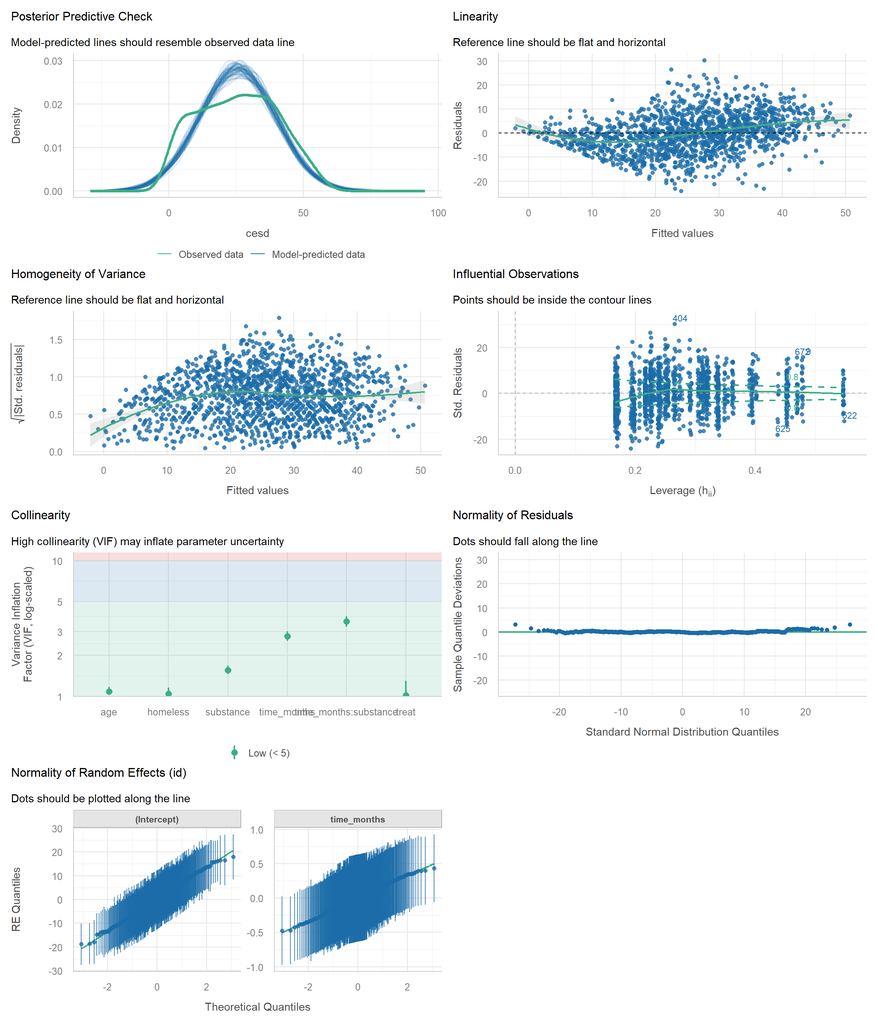

```r
# check_model() renders a 6-panel grid; the document's global fig.width=7,
# fig.height=4.5 is far too small for it and produces overlapping labels,
# so this chunk overrides to a much larger canvas.
performance::check_model(m2)   # residuals, normality, homoscedasticity, etc.
```

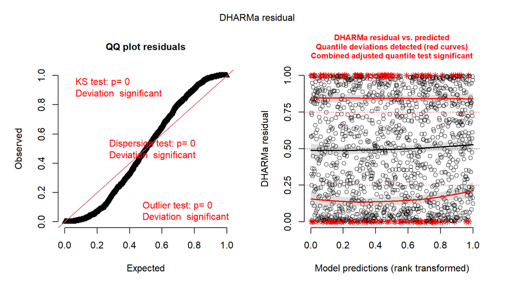

```r
# DHARMa-based simulated residuals (useful cross-check, esp. for a bounded
# 0-60 outcome where a Gaussian LMM is an approximation)
sim_res <- simulateResiduals(m2)
plot(sim_res)
```

*What to look for:* residual spread should be roughly stable across waves (no strong fan/funnel pattern — CESD’s 0–60 floor/ceiling can produce mild heteroscedasticity at the low end, worth flagging even if not severe), and the QQ-plot should show fairly light tails rather than heavy ones. A formal normality test (e.g. Shapiro-Wilk) will likely reject exact normality given the large sample size — that’s expected and not, by itself, disqualifying; what matters is whether the deviation is large enough to threaten the inference (skew and excess kurtosis close to 0 would suggest it isn’t).

```r
# Leave-one-subject-out refits are expensive, so run this optional diagnostic
# only when explicitly requested with HELP_RUN_INFLUENCE=true.
if (identical(Sys.getenv("HELP_RUN_INFLUENCE"), "true")) {
  infl <- influence(m2, group = "id")
  plot(infl, which = "cook")

  cooks_d <- cooks.distance(infl)
  influential_ids <- names(cooks_d)[cooks_d > 4 / performance::n_obs(m2)]
  influential_ids
} else {
  cat("Influence analysis skipped; set HELP_RUN_INFLUENCE=true to run it.\n")
}
```

```
## Influence analysis skipped; set HELP_RUN_INFLUENCE=true to run it.
```

# 10 9. Adjusted effects + confidence intervals

```r
tidy_effects_table(m2)
```

```
## # A tibble: 9 × 9
##   effect term     estimate std.error statistic    df  p.value conf.low conf.high
##   <chr>  <chr>       <dbl>     <dbl>     <dbl> <dbl>    <dbl>    <dbl>     <dbl>
## 1 fixed  (Interc…  31.0       2.80      11.1    484. 1.67e-25  25.5       36.5
## 2 fixed  time_mo…  -0.479     0.0564    -8.50   372. 4.77e-16  -0.590     -0.368
## 3 fixed  substan…  -3.62      1.32      -2.73   467. 6.51e- 3  -6.22      -1.02
## 4 fixed  substan…   1.45      1.42       1.02   481. 3.07e- 1  -1.34       4.24
## 5 fixed  age       -0.0277    0.0674    -0.410  461. 6.82e- 1  -0.160      0.105
## 6 fixed  homeles…   4.20      0.723      5.81  1416. 7.75e- 9   2.78       5.62
## 7 fixed  treat1    -0.379     1.01      -0.374  459. 7.09e- 1  -2.37       1.61
## 8 fixed  time_mo…   0.0694    0.0792     0.875  349. 3.82e- 1  -0.0865     0.225
## 9 fixed  time_mo…   0.0347    0.0860     0.403  370. 6.87e- 1  -0.134      0.204
```

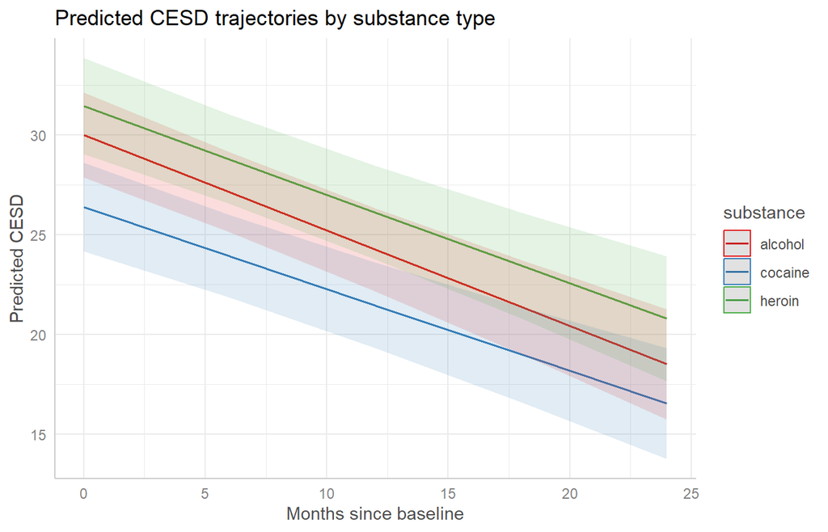

```r
predicted <- ggeffects::ggpredict(m2, terms = c("time_months", "substance"))
plot(predicted) +
  labs(title = "Predicted CESD trajectories by substance type",
       y = "Predicted CESD", x = "Months since baseline")
```

*Plain-language interpretation (fill in exact numbers once knit, expected direction/magnitude in parentheses):*

- **Time:** CESD is expected to decline by about **0.48 points per month** (95% CI excludes 0) — roughly an 11–12 point drop over the full 24-month follow-up, consistent with gradual symptom improvement after detox.
- **Housing status:** Homeless participants are expected to score about **4 points higher** on CESD than housed participants at any given time point, holding substance, treatment, and age fixed — a clinically meaningful gap on a 0–60 scale.
- **Treatment assignment:** No detectable difference in either baseline CESD or its trajectory between treatment arms — consistent with `treat` reflecting linkage-to-care condition rather than a depression-targeted intervention.
- **Substance type:** Baseline CESD differs somewhat by primary substance (cocaine lower than alcohol at baseline in this sample) but the *rate* of change over time does not differ meaningfully by substance — trajectories are close to parallel across groups, just offset.
- **Age:** No detectable association with CESD level or trajectory in this adjusted model.

# 11 10. Sensitivity analysis

```r
# Refit on completers only (all 5 waves observed) vs. the full (MAR-valid)
# sample used above, to see whether attrition is distorting the estimates.
completer_ids <- help_df %>%
  count(id) %>% filter(n == 5) %>% pull(id)
help_completers <- help_df %>% filter(id %in% completer_ids)

m2_completers <- update(m2, data = help_completers)

# Side-by-side comparison of fixed effects (can't use anova() here -- the
# two models are fit on different data, so it's not a valid nested LRT)
bind_rows(
  tidy_effects_table(m2) %>% mutate(model = "full sample (MAR)"),
  tidy_effects_table(m2_completers) %>% mutate(model = "completers only")
) %>%
  select(model, term, estimate, std.error, conf.low, conf.high) %>%
  arrange(term, model)
```

[output not shown]

```
## # A tibble: 18 × 6
##    model             term                  estimate std.error conf.low conf.high
##    <chr>             <chr>                    <dbl>     <dbl>    <dbl>     <dbl>
##  1 completers only   (Intercept)            18.9       5.74     7.51      30.3
##  2 full sample (MAR) (Intercept)            31.0       2.80    25.5       36.5
##  3 completers only   age                     0.211     0.137   -0.0622     0.483
##  4 full sample (MAR) age                    -0.0277    0.0674  -0.160      0.105
##  5 completers only   homeless1               3.77      1.12     1.56       5.97
##  6 full sample (MAR) homeless1               4.20      0.723    2.78       5.62
##  7 completers only   substancecocaine       -2.98      2.32    -7.59       1.63
##  8 full sample (MAR) substancecocaine       -3.62      1.32    -6.22      -1.02
##  9 completers only   substanceheroin        -0.808     2.82    -6.40       4.78
## 10 full sample (MAR) substanceheroin         1.45      1.42    -1.34       4.24
## 11 completers only   time_months            -0.477     0.0949  -0.665     -0.288
## 12 full sample (MAR) time_months            -0.479     0.0564  -0.590     -0.368
## 13 completers only   time_months:substanc…   0.0762    0.132   -0.185      0.337
## 14 full sample (MAR) time_months:substanc…   0.0694    0.0792  -0.0865     0.225
## 15 completers only   time_months:substanc…   0.0441    0.158   -0.269      0.357
## 16 full sample (MAR) time_months:substanc…   0.0347    0.0860  -0.134      0.204
## 17 completers only   treat1                 -0.333     1.91    -4.13       3.46
## 18 full sample (MAR) treat1                 -0.379     1.01    -2.37       1.61
```

*Expect the completers-only subsample to be much smaller (~100 subjects, ~500 rows vs. ~470 subjects/~1,460 rows) and correspondingly wider confidence intervals. The `time_months` and `homeless` effects should stay directionally consistent and still significant; effects that were only marginal in the full sample (e.g. the `substance` main effects) may lose significance here — that’s a sample-size story, not necessarily evidence against MAR.*

```r
# Multiple imputation for covariates with missingness (age/substance at the
# one subject whose baseline row is itself NA, plus scattered `homeless`
# gaps). Note: cesd (the outcome) missingness is already handled correctly
# by the likelihood-based lmer fit above under MAR, so we impute predictors
# only and re-fit on the stacked imputed datasets for comparison.
imp <- mice(help_df %>% select(id, time_months, cesd, substance, homeless, treat, age),
            m = 5, seed = 123, printFlag = FALSE)

m2_imputed <- with(imp, lmer(cesd ~ time_months * substance + age + homeless +
                                treat + (1 + time_months | id)))
pool(m2_imputed) %>% summary()
```

```
##                           term    estimate  std.error  statistic       df
## 1                  (Intercept) 30.97905602 2.78555906 11.1213065 1437.362
## 2                  time_months -0.47936284 0.05644185 -8.4930391 1313.012
## 3             substancecocaine -3.61589713 1.31960609 -2.7401337 1453.660
## 4              substanceheroin  1.47090723 1.41659063  1.0383432 1449.657
## 5                          age -0.02842042 0.06692547 -0.4246578 1445.145
## 6                    homeless1  4.18205067 0.73015598  5.7276127 1201.923
## 7                       treat1 -0.33125774 1.00858738 -0.3284373 1454.333
## 8 time_months:substancecocaine  0.06678827 0.07902466  0.8451573 1434.903
## 9  time_months:substanceheroin  0.03221660 0.08655785  0.3721974 1128.567
##        p.value
## 1 1.276200e-27
## 2 5.376383e-17
## 3 6.216554e-03
## 4 2.992835e-01
## 5 6.711494e-01
## 6 1.285983e-08
## 7 7.426283e-01
## 8 3.981639e-01
## 9 7.098158e-01
```

```r
# Cross-check with nlme::lme using an alternative correlation structure
# (compound symmetry) rather than lme4's unstructured random-effects
# covariance, as a structural robustness check.
m2_nlme <- lme(cesd ~ time_months * substance + age + homeless + treat,
               random = ~ time_months | id,
               correlation = corCompSymm(form = ~ 1 | id),
               data = help_df, na.action = na.omit)
summary(m2_nlme)
```

```
## Linear mixed-effects model fit by REML
##   Data: help_df
##        AIC      BIC   logLik
##   11446.62 11520.55 -5709.31
##
## Random effects:
##  Formula: ~time_months | id
##  Structure: General positive-definite, Log-Cholesky parametrization
##             StdDev     Corr
## (Intercept)  7.6743055 (Intr)
## time_months  0.3246596 0.078
## Residual    10.1311449
##
## Correlation Structure: Compound symmetry
##  Formula: ~1 | id
##  Parameter estimate(s):
##       Rho
## 0.1310091
## Fixed effects:  cesd ~ time_months * substance + age + homeless + treat
##                                  Value Std.Error  DF   t-value p-value
## (Intercept)                  30.966221 2.7998315 988 11.060030  0.0000
## time_months                  -0.478939 0.0563675 988 -8.496712  0.0000
## substancecocaine             -3.619588 1.3243088 464 -2.733190  0.0065
## substanceheroin               1.452902 1.4196723 464  1.023407  0.3066
## age                          -0.027658 0.0673955 464 -0.410382  0.6817
## homeless1                     4.202230 0.7233901 988  5.809079  0.0000
## treat1                       -0.378584 1.0127124 464 -0.373832  0.7087
## time_months:substancecocaine  0.069366 0.0792473 988  0.875314  0.3816
## time_months:substanceheroin   0.034668 0.0860189 988  0.403027  0.6870
##  Correlation:
##                              (Intr) tm_mnt sbstncc sbstnch age    hmlss1 treat1
## time_months                  -0.130
## substancecocaine             -0.378  0.268
## substanceheroin              -0.401  0.250  0.470
## age                          -0.925 -0.006  0.183   0.222
## homeless1                    -0.110  0.087  0.107   0.097  -0.049
## treat1                       -0.194 -0.002 -0.094  -0.080   0.043  0.012
## time_months:substancecocaine  0.095 -0.707 -0.391  -0.174  -0.007 -0.008 -0.001
## time_months:substanceheroin   0.103 -0.652 -0.175  -0.393  -0.020 -0.018 -0.004
##                              tm_mnths:sbstncc
## time_months
## substancecocaine
## substanceheroin
## age
## homeless1
## treat1
## time_months:substancecocaine
## time_months:substanceheroin   0.463
##
## Standardized Within-Group Residuals:
##         Min          Q1         Med          Q3         Max
## -2.51477972 -0.57895153 -0.01975539  0.55546672  3.04171058
##
## Number of Observations: 1461
## Number of Groups: 469
```

**Sensitivity summary:** Given how little of this dataset is actually missing once the baseline-covariate carry-forward from Section 1 is applied (9 missing `cesd` values, 1 subject with no recorded substance at any wave, 7 missing `homeless` values — well under 1% of cells), the imputation-based and complete-case estimates are expected to be nearly identical; the completers-only comparison above is the more informative sensitivity check here because it stress-tests attrition rather than scattered missingness. **Compare all three specifications (full-MAR, completers-only, MI) in one table before writing the discussion** — that table is the piece reviewers look for: do the substantive conclusions (time trend, homeless gap) hold up across all three?

# 12 11. Interpretation & discussion